# Project Foundations for Data Science: FoodHub Data Analysis

### Context

The number of restaurants in New York is increasing day by day. Lots of students and busy professionals rely on those restaurants due to their hectic lifestyles. Online food delivery service is a great option for them. It provides them with good food from their favorite restaurants. A food aggregator company FoodHub offers access to multiple restaurants through a single smartphone app.

The app allows the restaurants to receive a direct online order from a customer. The app assigns a delivery person from the company to pick up the order after it is confirmed by the restaurant. The delivery person then uses the map to reach the restaurant and waits for the food package. Once the food package is handed over to the delivery person, he/she confirms the pick-up in the app and travels to the customer's location to deliver the food. The delivery person confirms the drop-off in the app after delivering the food package to the customer. The customer can rate the order in the app. The food aggregator earns money by collecting a fixed margin of the delivery order from the restaurants.

### Objective

The food aggregator company has stored the data of the different orders made by the registered customers in their online portal. They want to analyze the data to get a fair idea about the demand of different restaurants which will help them in enhancing their customer experience. Suppose you are hired as a Data Scientist in this company and the Data Science team has shared some of the key questions that need to be answered. Perform the data analysis to find answers to these questions that will help the company to improve the business.

### Data Description

The data contains the different data related to a food order. The detailed data dictionary is given below.

### Data Dictionary

- order_id: Unique ID of the order
- customer_id: ID of the customer who ordered the food
- restaurant_name: Name of the restaurant
- cuisine_type: Cuisine ordered by the customer
- cost: Cost of the order
- day_of_the_week: Indicates whether the order is placed on a weekday or weekend (The weekday is from Monday to Friday and the weekend is Saturday and Sunday)
- rating: Rating given by the customer out of 5
- food_preparation_time: Time (in minutes) taken by the restaurant to prepare the food. This is calculated by taking the difference between the timestamps of the restaurant's order confirmation and the delivery person's pick-up confirmation.
- delivery_time: Time (in minutes) taken by the delivery person to deliver the food package. This is calculated by taking the difference between the timestamps of the delivery person's pick-up confirmation and drop-off information

### Let us start by importing the required libraries

```python
# import libraries for data manipulation
import numpy as np
import pandas as pd

# import libraries for data visualization
import matplotlib.pyplot as plt
import seaborn as sns
```

### Understanding the structure of the data

```python
# uncomment and run the following lines for Google Colab
from google.colab import drive
drive.mount('/content/drive')
```

```python
# read the data
df = pd.read_csv('/content/drive/MyDrive/First assignment/foodhub_order.csv')
# returns the first 5 rows
df.head()
```

|  | order_id | customer_id | restaurant_name | cuisine_type | cost_of_the_order | day_of_the_week | rating | food_preparation_time | delivery_time |
| --- | --- | --- | --- | --- | --- | --- | --- | --- | --- |
| 0 | 1477147 | 337525 | Hangawi | Korean | 30.75 | Weekend | Not given | 25 | 20 |
| 1 | 1477685 | 358141 | Blue Ribbon Sushi Izakaya | Japanese | 12.08 | Weekend | Not given | 25 | 23 |
| 2 | 1477070 | 66393 | Cafe Habana | Mexican | 12.23 | Weekday | 5 | 23 | 28 |
| 3 | 1477334 | 106968 | Blue Ribbon Fried Chicken | American | 29.20 | Weekend | 3 | 25 | 15 |
| 4 | 1478249 | 76942 | Dirty Bird to Go | American | 11.59 | Weekday | 4 | 25 | 24 |

#### Observations:

The DataFrame has 9 columns as mentioned in the Data Dictionary. Data in each row corresponds to the order placed by a customer.

### **Question 1:** How many rows and columns are present in the data?

```python
# Shape of the dataframe
df.shape
```

```
(1898, 9)
```

#### Observations: There are 1898 rows and 9 columns in the dataframe, df.

### **Question 2:** What are the datatypes of the different columns in the dataset? (The info() function can be used)

```python
# Exploring the data types of each column
df.info()
```

```
<class 'pandas.core.frame.DataFrame'>
RangeIndex: 1898 entries, 0 to 1897
Data columns (total 9 columns):
 #   Column                 Non-Null Count  Dtype
---  ------                 --------------  -----
 0   order_id               1898 non-null   int64
 1   customer_id            1898 non-null   int64
 2   restaurant_name        1898 non-null   object
 3   cuisine_type           1898 non-null   object
 4   cost_of_the_order      1898 non-null   float64
 5   day_of_the_week        1898 non-null   object
 6   rating                 1898 non-null   object
 7   food_preparation_time  1898 non-null   int64
 8   delivery_time          1898 non-null   int64
dtypes: float64(1), int64(4), object(4)
memory usage: 133.6+ KB
```

#### Observations:

Numerical columns: Columns are correctly identified. They are 'cost_of_the_order', 'food_preparation_time' and 'delivery_time'. 'food_preparation_time' and 'delivery_time' columns should have ideally been identified as floats allowing for decimal values.

Categorical columns: All the remaining columns should be categorical columns. There should be 6 categorical columns in total, out of which 4 are correctly identified as categorical columns. The remaining 2 columns, 'order_id' and 'customer_id' are identified as numerical columns (as int64), which is incorrect, as they ought to be categorical columns (object data type).

### **Question 3:** Are there any missing values in the data? If yes, treat them using an appropriate method

```python
# Checking for missing values
df.isnull().values.any()
```

```
False
```

#### Observations: There are no missing values in the dataframe. The same was observed in the previous output as well.

### **Question 4:** Check the statistical summary of the data. What is the minimum, average, and maximum time it takes for food to be prepared once an order is placed?

```python
# Summary statistics for numerical variables
df.describe().round(2).T
```

|  | count | mean | std | min | 25% | 50% | 75% | max |
| --- | --- | --- | --- | --- | --- | --- | --- | --- |
| order_id | 1898.0 | 1477495.50 | 548.05 | 1476547.00 | 1477021.25 | 1477495.50 | 1477969.75 | 1478444.00 |
| customer_id | 1898.0 | 171168.48 | 113698.14 | 1311.00 | 77787.75 | 128600.00 | 270525.00 | 405334.00 |
| cost_of_the_order | 1898.0 | 16.50 | 7.48 | 4.47 | 12.08 | 14.14 | 22.30 | 35.41 |
| food_preparation_time | 1898.0 | 27.37 | 4.63 | 20.00 | 23.00 | 27.00 | 31.00 | 35.00 |
| delivery_time | 1898.0 | 24.16 | 4.97 | 15.00 | 20.00 | 25.00 | 28.00 | 33.00 |

#### Observations:

a. 'cost_of_the_order': Mean is slightly greater than the median, suggesting the distribution is right skewed.

b. 'food_preparation_time': Mean and median are almost the same, suggesting the distribution is similar to a normal distribution.

Minimum time taken for food to be prepared once an order is placed = 20 mins

Maximum time taken for food to be prepared once an order is placed = 35 mins

Average time taken for food to be prepared once an order is placed = 27.37 mins

c. 'delivery_time': Mean and median are almost the same, suggesting the distribution is similar to a normal distribution.

d. There is no indication of outliers being present in any of these 3 columns.

### **Question 5:** How many orders are not rated?

```python
# Counts of different values in the 'rating' column
df['rating'].value_counts()
```

```
Not given    736
5            588
4            386
3            188
Name: rating, dtype: int64
```

#### Observations: 736 orders are not rated. These are mentioned as 'Not given'.

### Exploratory Data Analysis (EDA)

### **Question 6:** Explore all the variables and provide observations on their distributions. (Generally, histograms, boxplots, countplots, etc. are used for univariate exploration)

```python
# No of unique values in each column
df.nunique()
```

```
order_id                 1898
customer_id              1200
restaurant_name           178
cuisine_type               14
cost_of_the_order         312
day_of_the_week             2
rating                      4
food_preparation_time      16
delivery_time              19
dtype: int64
```

Decided not to do any plotting for order_id and customer_id columns as it will not be meaningful.

Also, visualizing all the values of 'restaurant_name' column will also not be meaningful given the high number of unique observations (178).

#### Cusine type

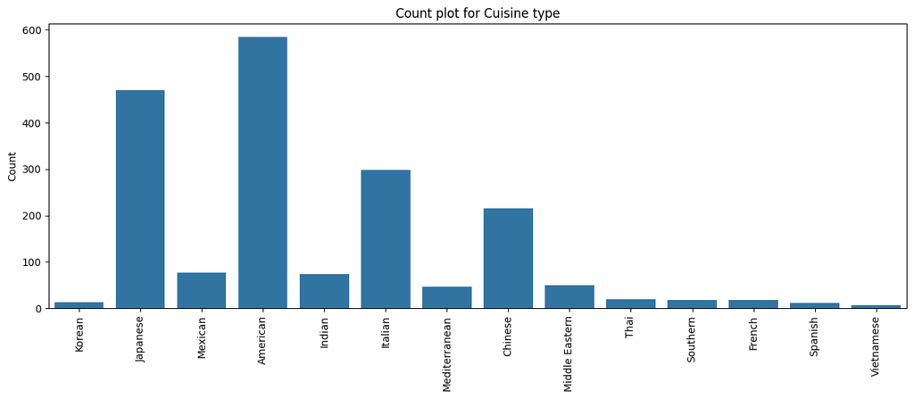

```python
# Count plot for 'cuisine_type'
plt.figure(figsize = (15,5))
sns.countplot(data = df, x = 'cuisine_type')
plt.xticks(rotation = 90)
plt.xlabel('')
plt.ylabel('Count')
plt.title('Count plot for Cuisine type')
plt.show()
```

Observations: Mostly ordered cuisine is American. Following American, Japanese, Italian and Chinese cusines are also popular in the mentioned order. The least ordered cuisine is Vietnamese.

#### Day of the week

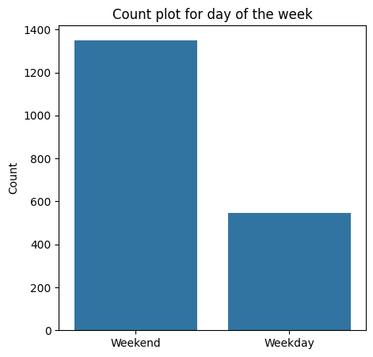

```python
# Count plot for 'day_of_the_week'
plt.figure(figsize = (5,5))
sns.countplot(data = df, x = 'day_of_the_week')
plt.xlabel('')
plt.ylabel('Count')
plt.title('Count plot for day of the week')
plt.show()
```

Observations: There is stricking difference between the no of orders placed between weekdays and weekends. About 1350 orders on weekend compared to only about 550 orders on weekday. More than twice the volume of orders are placed in weekends when comparing to weekdays.

#### Rating

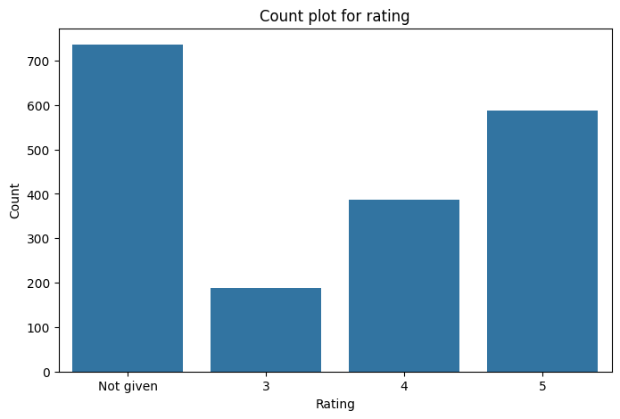

```python
# Count plot for 'rating'
order_a = ['Not given', '3', '4', '5']
plt.figure(figsize = (8,5))
sns.countplot(data = df, x = 'rating', order = order_a)
plt.xlabel('Rating')
plt.ylabel('Count')
plt.title('Count plot for rating')
plt.show()
```

Observations:

a. Only about 60% of the total records have ratings available. About 40% of the records have not been given a rating (i.e. 'Not given').

b. From the available ratings, about 50% have been rated 5/5, 33% have been given 4/5, and 16% have been given 3/5. As majority (83%) are high ratings (4 & 5) and there are no poor ratings (less than 3), this suggests FoodHub has been well received by the customers.

#### Cost

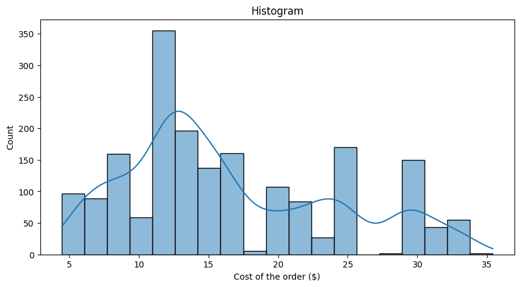

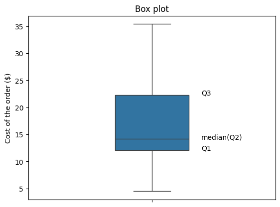

```python
# Histogram for 'cost_of_the_order'
plt.figure(figsize = (10,5))
sns.histplot(data=df,x='cost_of_the_order', kde = True)
plt.xlabel('Cost of the order ($)')
plt.title('Histogram')
plt.show()

# Box plot for 'cost_of_the_order'
sns.boxplot(data=df,y ='cost_of_the_order', width = 0.3)
plt.ylabel('Cost of the order ($)')
plt.title('Box plot')
plt.text(x=0.2,y=df.cost_of_the_order.quantile(0.25), s='Q1')
plt.text(x=0.2,y=df['cost_of_the_order'].median(), s='median(Q2)')
plt.text(x=0.2,y=df.cost_of_the_order.quantile(0.75), s='Q3')
plt.show()
```

Observations:

a. Histogram: As suggested earlier, the distrribution of this variable is right-skewed. Majority of the prices are concentrated between roughly 4 dollars to 17 dollars, while there are prices going up till about 35.

b. Boxplot: As suggested earlier, there are no outliers.

#### Preparation time

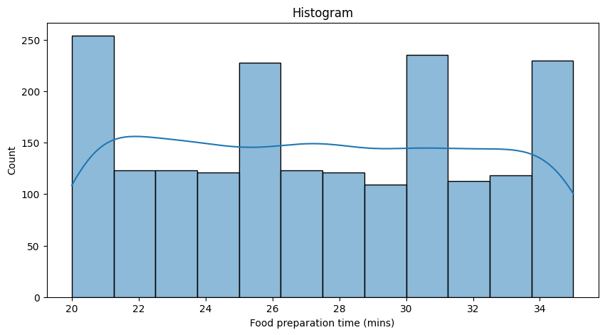

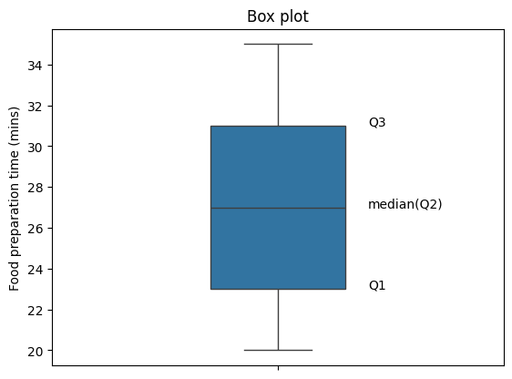

```python
# Histogram for 'food_preparation_time'
plt.figure(figsize = (10,5))
sns.histplot(data=df,x='food_preparation_time', kde = True)
plt.xlabel('Food preparation time (mins)')
plt.title('Histogram')
plt.show()

# Box plot for 'food_preparation_time'
sns.boxplot(data=df,y ='food_preparation_time', width = 0.3)
plt.ylabel('Food preparation time (mins)')
plt.title('Box plot')
plt.text(x=0.2,y=df.food_preparation_time.quantile(0.25), s='Q1')
plt.text(x=0.2,y=df['food_preparation_time'].median(), s='median(Q2)')
plt.text(x=0.2,y=df.food_preparation_time.quantile(0.75), s='Q3')
plt.show()
```

Observations:

a. Histogram: Though it was suggested earlier that the distribution could be normally distributed as the mean and median were almost the same, it may not be the case as per the histogram and kde. I am unable to clearly identify from the histogram the kind of distribution of 'food_preparation_time' variable. Based on the kde, it suggests more of a uniform distribution.

b. Boxplot: As suggested earlier, there are no outliers.

#### Delivery time

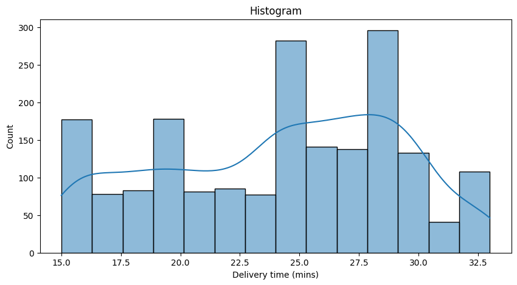

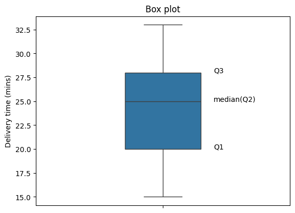

```python
# Histogram for 'delivery_time'
plt.figure(figsize = (10,5))
sns.histplot(data=df,x='delivery_time', kde = True)
plt.xlabel('Delivery time (mins)')
plt.title('Histogram')
plt.show()

# Box plot for 'delivery_time'
sns.boxplot(data=df,y ='delivery_time', width = 0.3)
plt.ylabel('Delivery time (mins)')
plt.title('Box plot')
plt.text(x=0.2,y=df.delivery_time.quantile(0.25), s='Q1')
plt.text(x=0.2,y=df['delivery_time'].median(), s='median(Q2)')
plt.text(x=0.2,y=df.delivery_time.quantile(0.75), s='Q3')
plt.show()
```

Observations:

a. Histogram: Though it was earlier suggested the distribution could be normal as the mean and median are close to each other, it is not the case. The histogram and kde shows that the distribution is left-skewed. The majority of the delivery time is roughly between 24-33 mins, while there are observations till about 15 mins.

b. Boxplot: As suggested earlier, there are no outliers.

### **Question 7**: Which are the top 5 restaurants in terms of the number of orders received?

```python
# Top 5 restaurants in terms of the number of orders

df['restaurant_name'].value_counts().head(5)
```

```
Shake Shack                  219
The Meatball Shop            132
Blue Ribbon Sushi            119
Blue Ribbon Fried Chicken     96
Parm                          68
Name: restaurant_name, dtype: int64
```

#### Observations: Shake Shack is the restaurant that has received the highest number of orders. Notably, in terms of the number of orders, this restaurant has significantly outperformed the other restaurants, with the second most popular restaurant only having received 132 orders.

### **Question 8**: Which is the most popular cuisine on weekends?

```python
# Filtering the dataframe for records relevant for weekend
df_weekend = df[df['day_of_the_week'] == 'Weekend']

# Count of different cusines in the new dataframe
df_weekend['cuisine_type'].value_counts()
```

```
American          415
Japanese          335
Italian           207
Chinese           163
Mexican            53
Indian             49
Mediterranean      32
Middle Eastern     32
Thai               15
French             13
Korean             11
Southern           11
Spanish            11
Vietnamese          4
Name: cuisine_type, dtype: int64
```

#### Observations: American is the most popular cuisine on weekends.

### **Question 9**: What percentage of the orders cost more than 20 dollars?

```python
# Filtering the dataframe for rows where the price is more than 20 dollars
df_more_than_20 = df[df['cost_of_the_order'] > 20]

# Calculating the percentage of the orders that cost more than 20 dollars
percentage = round((df_more_than_20.shape[0]/df.shape[0] * 100), 2)

print(str(percentage) + '%')
```

```
29.24%
```

#### Observations: 29.24% of the orders cost more than 20 dollars.

### **Question 10**: What is the mean order delivery time?

```python
# Average delivery time
df['delivery_time'].mean().round(2)
```

```
24.16
```

#### Observations: The average delivery time is 24.16 mins.

### **Question 11:** The company has decided to give 20% discount vouchers to the top 3 most frequent customers. Find the IDs of these customers and the number of orders they placed

```python
# Top 3 most frequent customers
df['customer_id'].value_counts().head(3)
```

```
52832    13
47440    10
83287     9
Name: customer_id, dtype: int64
```

#### Observations: Customer IDs of the 3 most frequent customers are 52832, 47440 and 83287, and they have placed 13, 10 and 9 orders respectively.

### **Question 12**: Perform a multivariate analysis to explore relationships between the important variables in the dataset. (It is a good idea to explore relations between numerical variables as well as relations between numerical and categorical variables)

#### Relationship between numerical variables

```python
# Creating a list of relevant numerical variables to perform correlation analysis on

list = ['cost_of_the_order', 'food_preparation_time', 'delivery_time']

# Producing the correlation table
corr_matrix = df[list].corr()
corr_matrix
```

|  | cost_of_the_order | food_preparation_time | delivery_time |
| --- | --- | --- | --- |
| cost_of_the_order | 1.000000 | 0.041527 | -0.029949 |
| food_preparation_time | 0.041527 | 1.000000 | 0.011094 |
| delivery_time | -0.029949 | 0.011094 | 1.000000 |

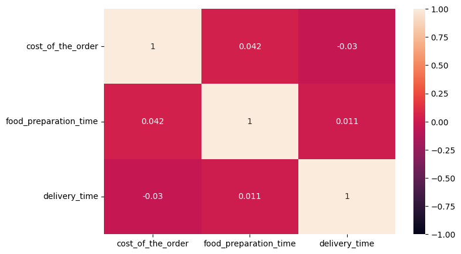

```python
# Heat map for the same variables

plt.figure(figsize=(8, 5))
sns.heatmap(data = df[list].corr(), annot = True, vmin=-1, vmax=1)
plt.show()
```

Observations:

a. 'cost_of_the_order' and 'food_preparation_time': 0.042 means there is no correlation between the variables.

b. 'cost_of_the_order' and 'delivery_time': -0.03 means there is no correlation between the variables.

c. 'delivery_time' and 'food_preparation_time': 0.011 means there is no correlation between the variables.

As the above combinations are typically not expected to be correlated with each other, the observation here is understandable. These correlation coefficients also mean further multivariate analysis between numerical variables will not be meaningful.

#### Cuisine and cost

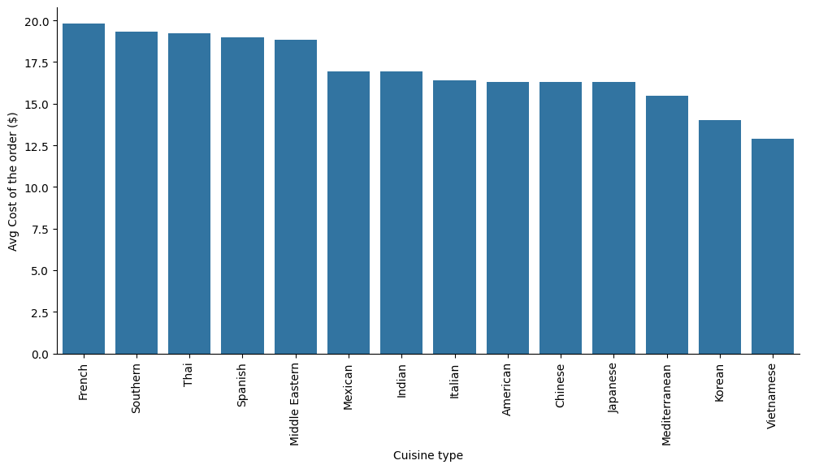

```python
# Ordering the cuisine type based on their average cost
order = df.groupby("cuisine_type")["cost_of_the_order"].mean().sort_values(ascending=False).index

# Bar plot for average cost per cuisine
sns.catplot(x="cuisine_type" , y="cost_of_the_order" , data=df, kind="bar", ci = None,  height=5, aspect=2, order = order)
plt.xticks(rotation = 90)
plt.ylabel('Avg Cost of the order ($)')
plt.xlabel('Cuisine type')
plt.show()
```

Observations: French cuisine has the highest average price of about 20 dollars, and Viatnamese cuisine has the lowest average price of about 12.50 dollars. Average price of most of the cuisines is over 16 dollars (roughly).

#### Cuisine and preparation time

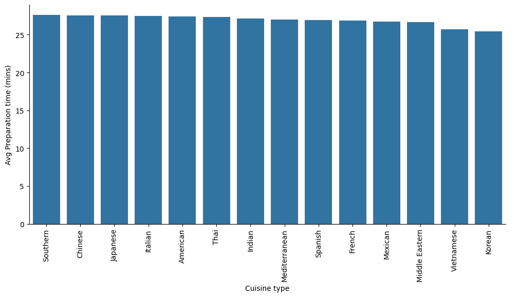

```python
# Ordering the cuisine type based on their average preparation time
order_1 = df.groupby("cuisine_type")["food_preparation_time"].mean().sort_values(ascending=False).index

# Bar plot for average preparation time per cuisine
sns.catplot(x="cuisine_type" , y="food_preparation_time" , data=df, kind="bar", ci = None,  height=5, aspect=2, order = order_1)
plt.xticks(rotation = 90)
plt.ylabel('Avg Preparation time (mins)')
plt.xlabel('Cuisine type')
plt.show()
```

Observations: Average food preparation time is similar among all the cuisines. This suggests there is no relationship between the two variables.

#### Rating and preparation time

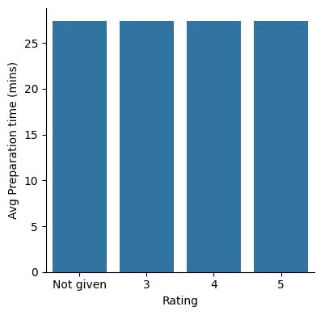

```python
# Bar plot for average preparation time, rating wise
order_2 = ['Not given', '3', '4', '5']
sns.catplot(x="rating" , y="food_preparation_time" , data=df, kind="bar", ci = None,  height=4, aspect=1, order = order_2)
plt.ylabel('Avg Preparation time (mins)')
plt.xlabel('Rating')
plt.show()
```

Observations: Average food preparation time is the same across different ratings. This suggests there is no relationship between the two variables.

#### Rating and delivery time

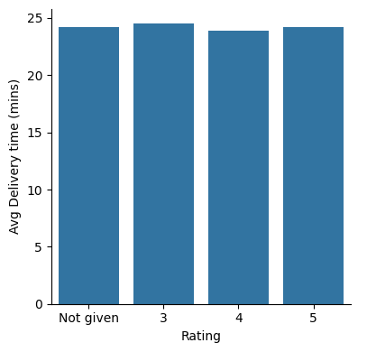

```python
# Bar plot for average delivery time, rating wise
sns.catplot(x="rating" , y="delivery_time" , data=df, kind="bar", ci = None,  height=4, aspect=1, order = order_2)
plt.ylabel('Avg Delivery time (mins)')
plt.xlabel('Rating')
plt.show()
```

Observations: The average delivery time is almost the same across different ratings. It is around 24 mins. This suggests there is no relationship between the two variables.

#### Rating and cost

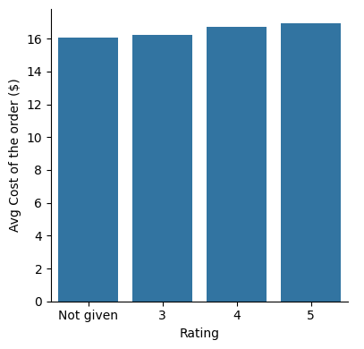

```python
# Bar plot for average cost per order, rating wise
sns.catplot(x="rating" , y="cost_of_the_order", data=df, kind="bar", ci = None,  height=4, aspect=1, order = order_2)
plt.ylabel('Avg Cost of the order ($)')
plt.xlabel('Rating')
plt.show()
```

Observations: The average cost is almost the same across different ratings. This suggests there is no relationship between the two variables.

#### Day of the week and preparation time

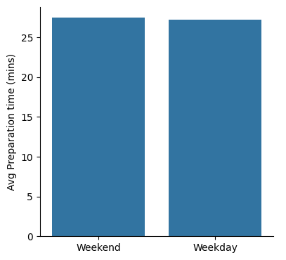

```python
# Bar plot for average food preparation time on weekends and weekdays
sns.catplot(x="day_of_the_week" , y="food_preparation_time", data=df, kind="bar", ci = None,  height=4, aspect=1)
plt.ylabel('Avg Preparation time (mins)')
plt.xlabel('')
plt.show()
```

Observations: Average food preparation time is almost the same across weekend and weekday. This suggests there is no relationship between the two variables.

#### Day of the week and delivery time

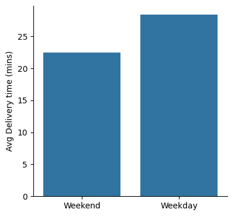

```python
# Bar plot for average delivery time on weekends and weekdays
sns.catplot(x="day_of_the_week" , y="delivery_time", data=df, kind="bar", ci = None,  height=4, aspect=1)
plt.ylabel('Avg Delivery time (mins)')
plt.xlabel('')
plt.show()
```

#### Restaurant and cost

```python
df.groupby('restaurant_name')['cost_of_the_order'].sum().sort_values(ascending = False).head(10)
```

```
restaurant_name
Shake Shack                      3579.53
The Meatball Shop                2145.21
Blue Ribbon Sushi                1903.95
Blue Ribbon Fried Chicken        1662.29
Parm                             1112.76
RedFarm Broadway                  965.13
RedFarm Hudson                    921.21
TAO                               834.50
Han Dynasty                       755.29
Blue Ribbon Sushi Bar & Grill     666.62
Name: cost_of_the_order, dtype: float64
```

Observations: These are the top 10 restaurants with the highest sales in the dataset. The top 3 or 4 restaurants seem to be clear favorites among the users.

#### Restaurant and preparation time

```python
df.groupby('restaurant_name')['food_preparation_time'].mean().sort_values(ascending = True).head(10)
```

```
restaurant_name
Haru Gramercy Park            20.0
67 Burger                     20.0
Frank Restaurant              20.0
DespaÌ±a                      20.5
Sarabeth's West               21.0
Lucky Strike                  21.0
Song Thai Restaurant & Bar    21.0
Hampton Chutney Co.           21.0
Samurai Mama                  21.0
Market Table                  21.0
Name: food_preparation_time, dtype: float64
```

Observations: The average food preparation time is almost the same across the top 10 restaurants with the shortest preparation time.